# Introduction to tidy data and network science in R

### Facetting

Separating data into a group of several plots is done with *facets*:

```r
gg_hist <- ggplot(diamonds, aes(x = carat, fill = cut)) +
  geom_histogram() +
  facet_grid(cut ~ ., scales = 'free')
```

An example of a barplot (histogram for discrete variable) with 2d facetting:

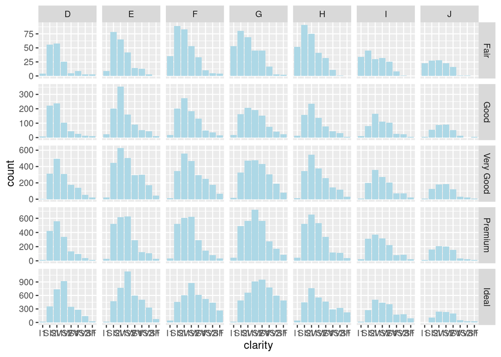

```r
ggplot(diamonds, aes(x = clarity)) +
  geom_bar(fill = 'lightblue') +
  facet_grid(cut ~ color, scales = 'free')
```

### Changing color schemes and other scales

There are tons of different approaches to customizing color with ggplot, and its easy to get overwhelmed! Here we’ll focus on the essentials and leave you to research different color palettes or making your own.

Basically, color is changed through scaling a color aesthetic (`col` or `fill`). Going back to our histogram example, here we use one of the color palettes provided by `RColorBrewer` for discrete variables:

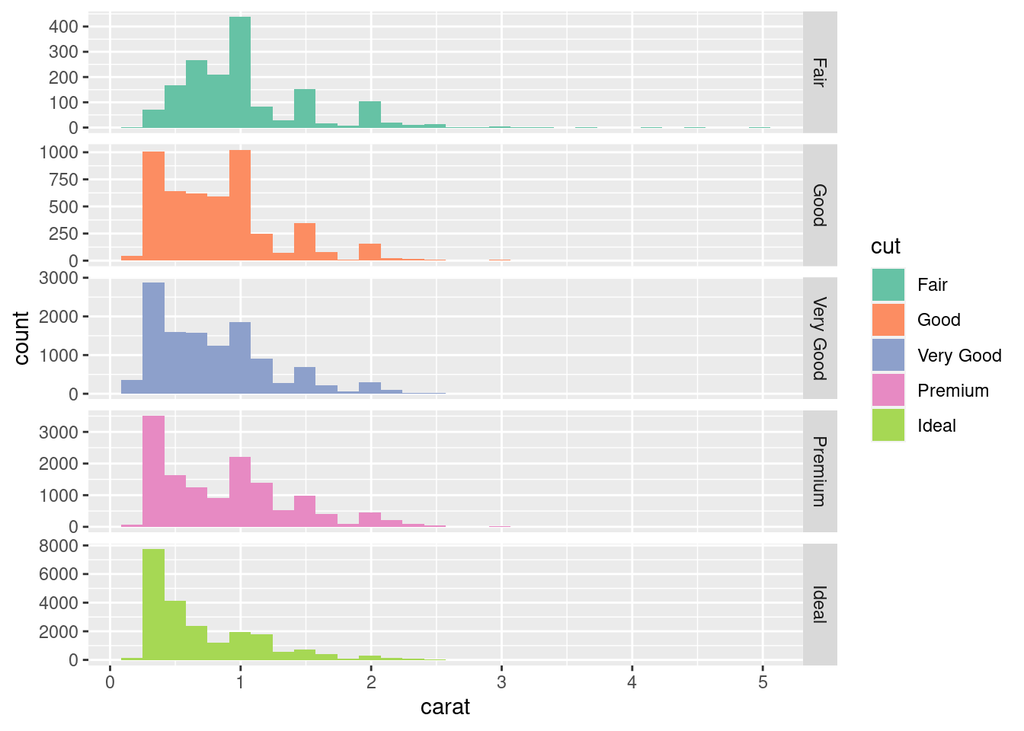

```r
library(RColorBrewer)

my_brew_pal <- brewer.pal(8, 'Set2')

gg_hist +
  scale_fill_discrete(type = my_brew_pal)
```

As we see above, a color palette can be stored and used in multiple plots. For presentations or papers, it can be nice to have a set of specific colors fixed for a variable of interest. An easy way to do this in ggplot is with `scale_*_manual`. Say we want all plots using a mapping with `cut` to have consistent colors:

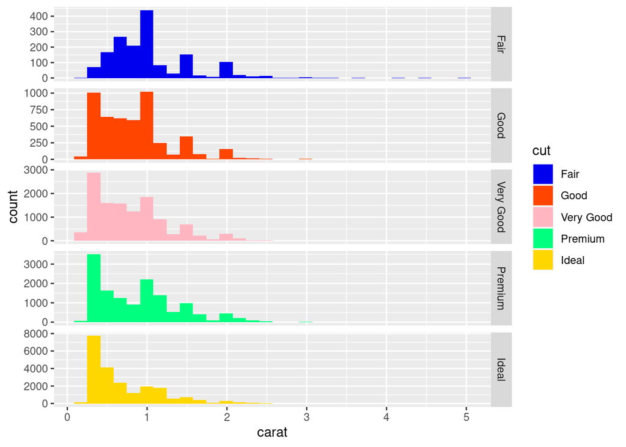

```r
my_pal <- c('blue2', 'orangered', 'lightpink', 'springgreen', 'gold')
names(my_pal) <- levels(diamonds$cut)

gg_hist +
  scale_fill_manual(values = my_pal)
```

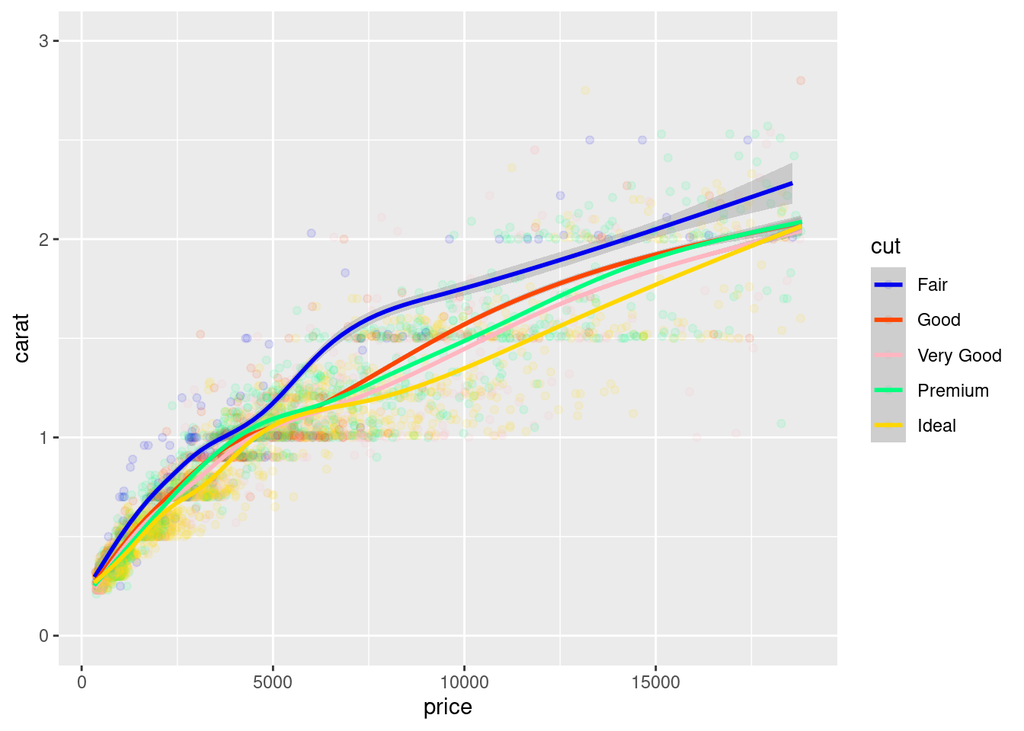

```r
ggplot(diamonds, aes(price, carat, col = cut)) +
  geom_point(alpha = 0.1, data = slice_sample(diamonds, prop = 0.1)) +
  geom_smooth() +
  scale_color_manual(values = my_pal) +
  ylim(0, 3)
```

In general, use `scale_*_discrete` or `scale_*_continuous` if you want to provide existing palettes or do other scaling functions (we’ll see another use of scale in a moment), and `scale_*_manual` for making a discrete palette by hand.

Aesthetics other than color can be scaled in much the same way. A common example is the `shape` aesthetic.

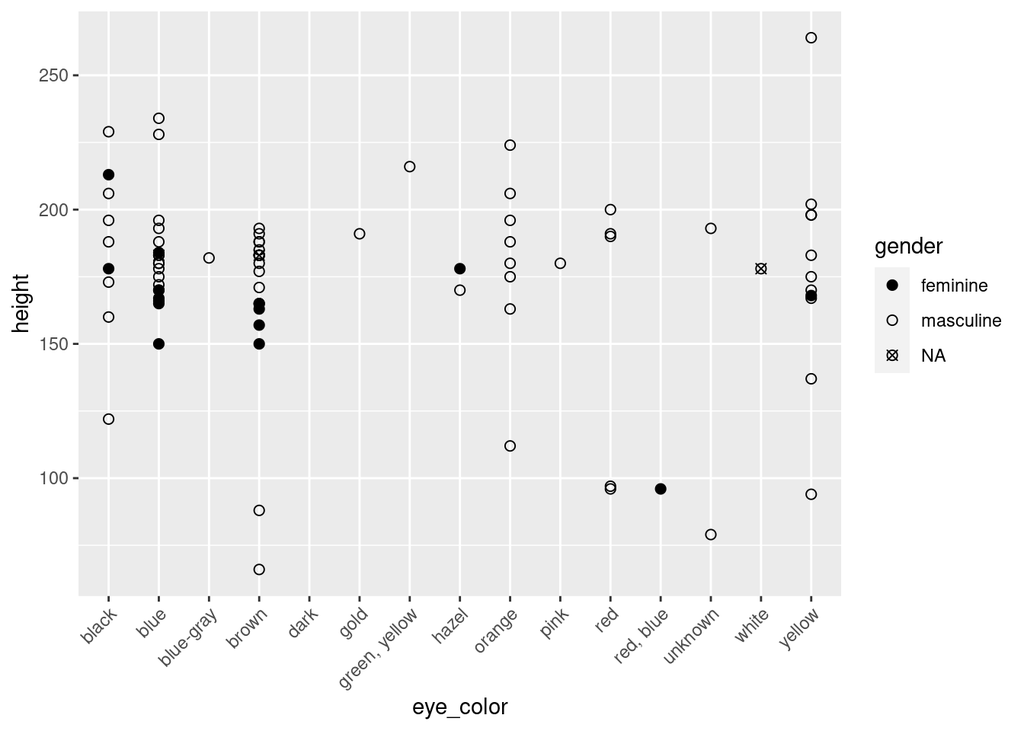

```r
ggplot(starwars, aes(eye_color, height, shape = gender)) + # col is continuous here
  geom_point(size = 2) +
  scale_shape_manual(values = c(19, 1), na.value = 13) +
  scale_x_discrete(guide = guide_axis(angle = 45))
```

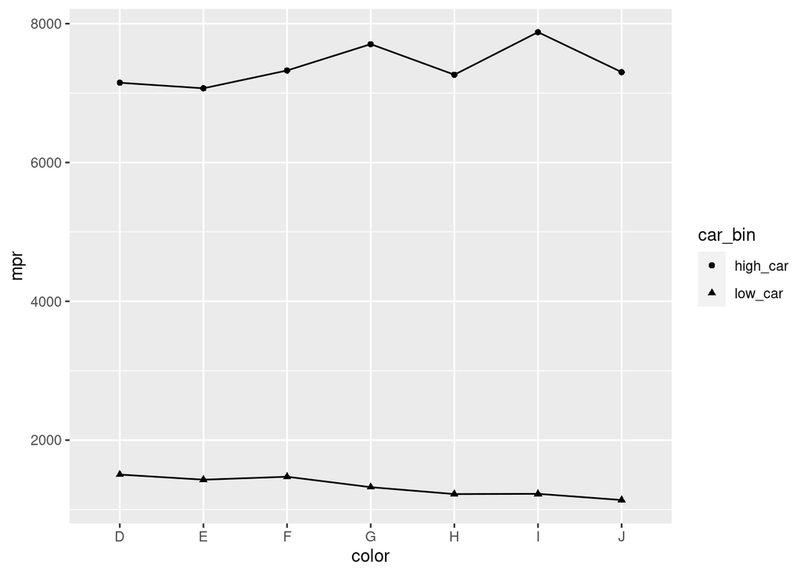

```r
diamonds |>
  mutate(car_bin = ifelse(carat < mean(carat), 'low_car', 'high_car')) |>
  group_by(car_bin, color) |>
  summarize(mpr = mean(price)) |>
  ggplot(aes(color, mpr, shape = car_bin, group = car_bin)) +
  geom_point() +
  geom_line()
```

### Going further

- The [R Graphics Cookbook](https://r-graphics.org/) has tons of examples for all things ggplot.
- Chapter 3 in R4DS is a good review of ggplot concepts and basics, with exercises.

# Bonus: Intro to Network Science with `tidygraph` + `ggraph`

`tidygraph` is a package for constructing and analyzing graphs with a workflow similar to tidyr/dplyr, and `ggraph` is a package similar to ggplot for visualization.

In tidygraph, a graph is represented with two tibbles: one of nodes (vertices) and one of edges (links). These tibbles are bundled together as one object called a `tbl_graph`.

```r
(graph <- create_ring(10))
```

[output not shown]

In ggraph, a graph is plotted in “layers” just like ggplot. There are specific geoms for nodes and edges:

```r
gg_net <- ggraph(graph) +
  geom_node_point(color = 'blue', size = 5)
```

```
## Using `stress` as default layout
```

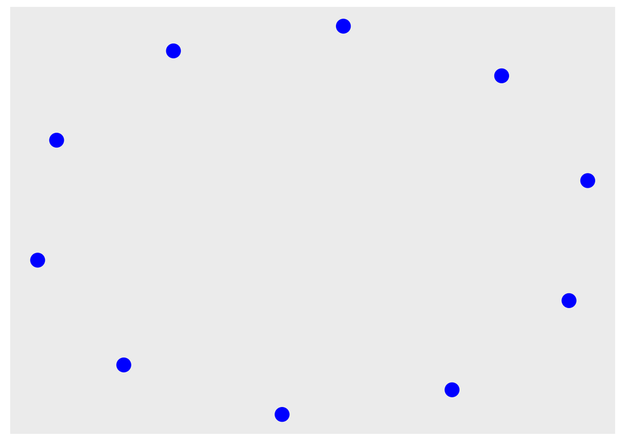

```r
gg_net # just the nodes
```

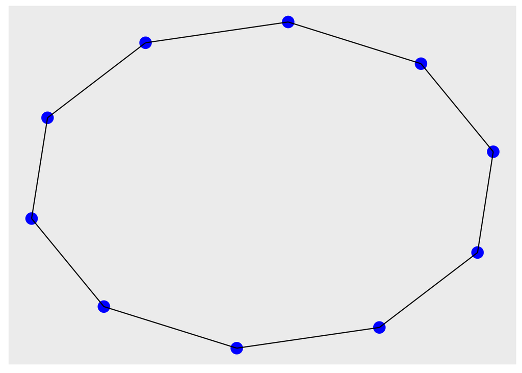

```r
gg_net +
  geom_edge_link() # now add the edges on top
```

### `dplyr` verbs on graphs

Since a `tbl_graph` is made of tibbles, we can use all the familiar functions on them:

```r
graph <- graph |>
  mutate(name = fruit[1:n()])
```

```r
graph <- graph |>
  activate(edges) |>
  mutate(weight = runif(n(), 1, 5))
```

**Info**

`%N>%` can be used as shorthand for `|> activate(nodes) |>`, and `%E>%` for activating edges

Attributes can be used in aesthetic mappings when plotting. As with all geoms, check which aesthetics can be controlled with a mapping with `?geom_node_*` etc.

```
## Using `stress` as default layout
```

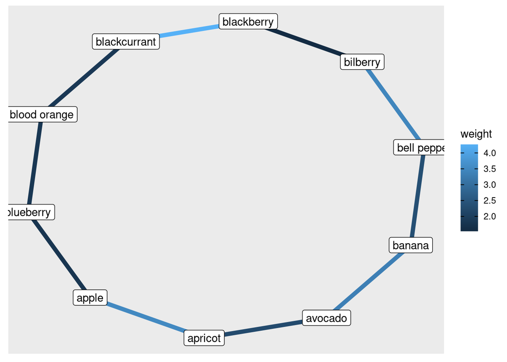

```r
ggraph(graph) +
  geom_edge_link(mapping = aes(edge_color = weight), edge_width = 2) +
  geom_node_label(mapping = aes(label = name))
```

### Specialized verbs on graphs

In addition to the usual tidyverse functions, there are many new verbs specific to network science, such as for finding the shortest distance between two nodes or calculating a node’s degree. These can be useful, for example, for richer visualization.

In the following example, we generate a network using the famous Erdős–Rényi model, then compute two measures of *node centrality*, or how “connected” a node is. The *degree* is the number of neighbors and the *page rank* is from the formula for ordering web results in Google’s early days.

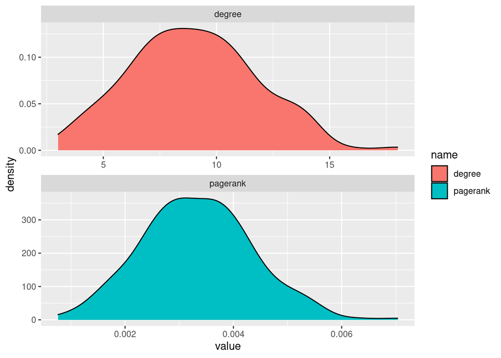

```r
graph <- play_erdos_renyi(300, p = 0.03) |>
  mutate(
    degree = centrality_degree(),
    pagerank = centrality_pagerank()
  )

graph |>
  as_tibble() |>
  pivot_longer(c(degree, pagerank)) |>
  ggplot(aes(x = value, fill = name)) +
  geom_density() +
  facet_wrap(~name, scales = 'free', nrow = 2)
```

```
## Using `stress` as default layout
```

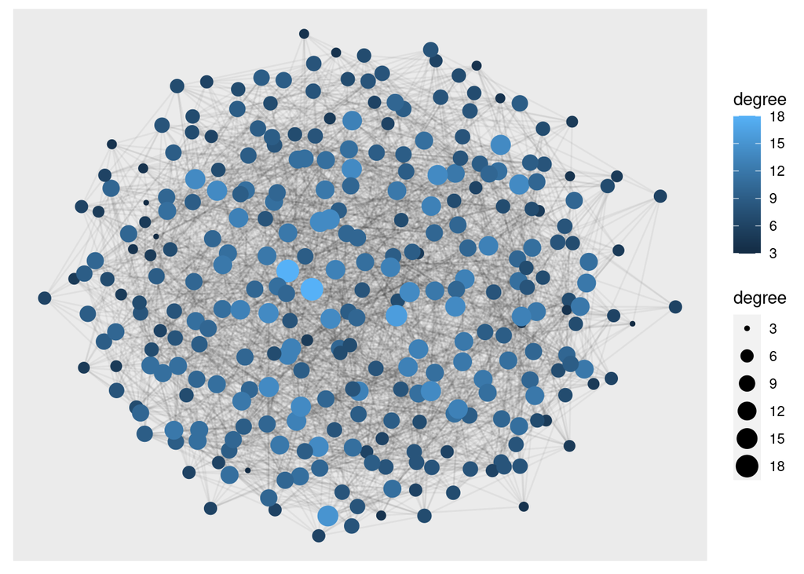

```r
ggraph(graph) +
  geom_edge_link0(alpha = 0.05) + # use edge0 family for faster plotting
  geom_node_point(aes(col = degree, size = degree))
```

One important type of network operation is *clustering*, where group-level patterns are extracted from the data. The basic motive behind clustering is that nodes within clusters should tend to be more connected with each other than with nodes of other clusters. Many different clustering algorithms have been proposed, and tidygraph supports the most popular ones with the `group_*` functions.

```
## Using `stress` as default layout
```

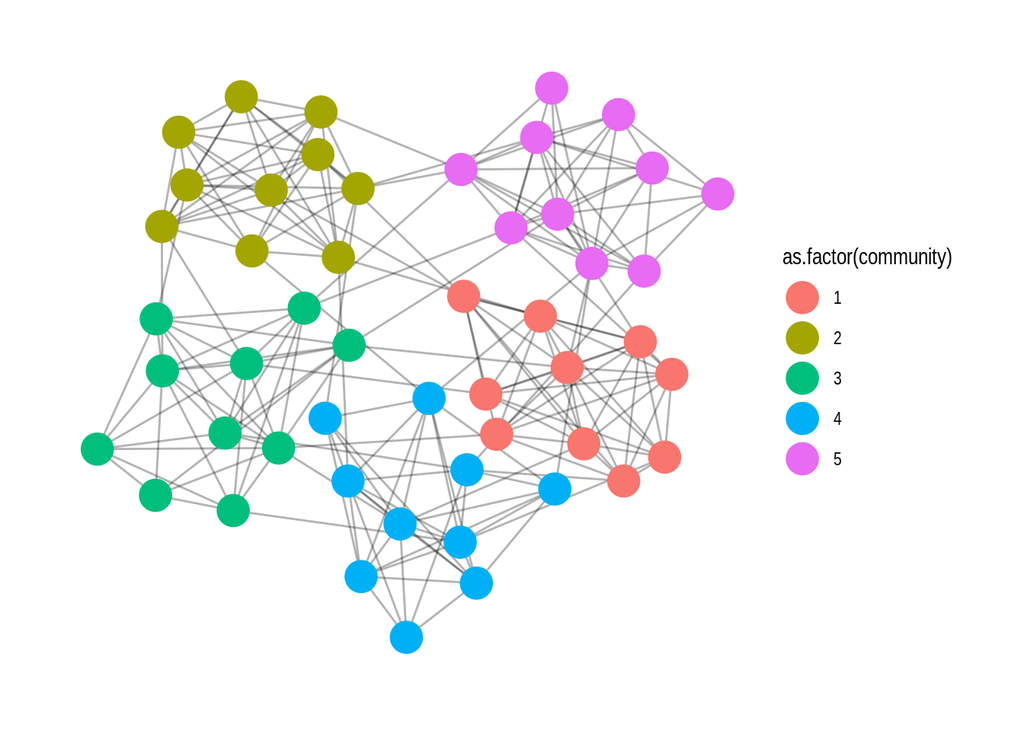

```r
play_islands(n_islands = 5, size_islands = 10, p_within = 0.8, m_between = 3) |>
  mutate(community = group_fast_greedy()) |> # classic method of maxing modularity
  ggraph() +
  geom_edge_link(alpha = 0.3) +
  geom_node_point(aes(color = as.factor(community)), size = 7) +
  theme_graph() # ggraph's provided theme: lots of customiziation is available!
```

### Epidemics on networks

To show more `tidygraph` functionality as part of a more realistic workflow, we will be implementing a simple stochastic epidemiological model. Our infection process will spread over a graph based on two rules.

1. An uninfected, or *susceptible*, node can become infected from any neighbor that is infected, independently with probability `beta`
2. A node that is already infectious can recover with probability `alpha`

In epidemiological modeling, this model is known as the *SIS* model because a node’s state can only go from susceptible to infectious to susceptible again.

The workhorse behind our implementation will be `tidygraph::map_local`, which extracts the neighborhood of each node as a list of subgraphs, then maps a function `.f` over each of these graphs and returns the result. From the function’s documentation:

> The function provided to `.f` will be called with the following arguments in addition to those supplied through `...`:
> - `neighborhood`: The neighborhood graph of the node
> - `graph`: The full tbl_graph object
> - `node`: The index of the node currently mapped over

So, our main task will be to provide an `.f` that takes these arguments and updates the infection status of `node` by looking at its `neighborhood` for other infectious nodes.

```
## Using `stress` as default layout
```

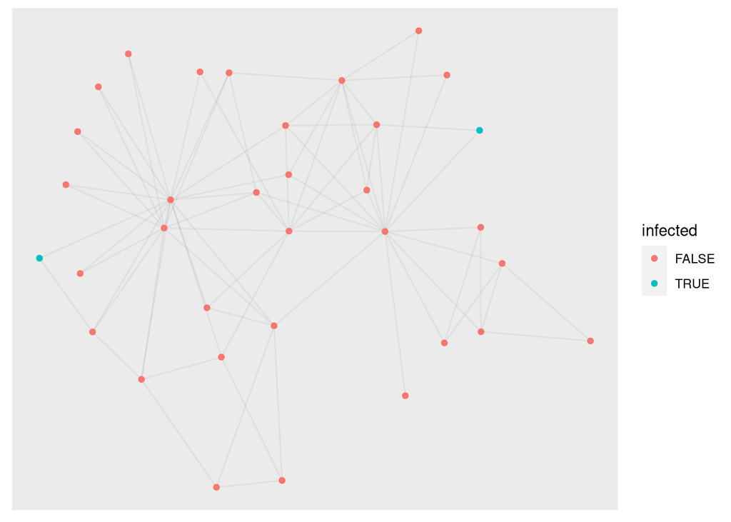

```r
init_outbreak <- function(graph, nseed=1) {
    init <- sample(length(graph), nseed)

    graph |>
        mutate(infected = ifelse(node_idx %in% init, TRUE, FALSE))
}

update_node <- function(neighborhood, graph, node, inf_stats, beta = 0.3, alpha = 0.1) {
    if (inf_stats[node]) # if node is already infected, rec. with prob 0.1
        if (runif(1) < alpha) FALSE else TRUE

    ninf <- sum(pull(neighborhood, infected)) # get the inf. status of each neighbor
    if (ninf > 0) {
        inter <- runif(ninf)
        if (any(inter < beta)) # pass on infection with ind. probabilities 0.3
            return(TRUE)
    }
    return(FALSE)
}

run_step <- function(graph) {
    graph |>
        mutate(infected=map_local_lgl(.f = update_node, inf_stat = infected))
}

plot_outbreak <- function(graph) {
    ggraph(graph) +
        geom_edge_link0(alpha = 0.05) +
        geom_node_point(aes(col = infected))
}

graph0 <- create_notable("Zachary") |>
    mutate(node_idx = 1:n()) |>
    init_outbreak(nseed = 2)

plot_outbreak(graph0) # plot the initial state
```

```
## Using `stress` as default layout
```

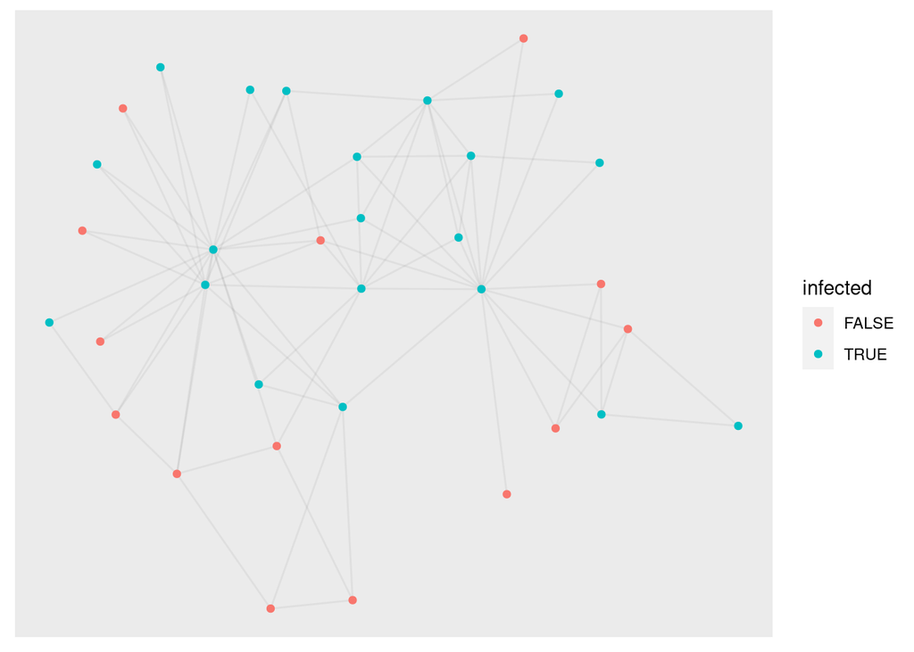

```r
reduce(1:10, ~run_step(.x), .init = graph0) |>
    plot_outbreak() # plot result after running 10 steps
```

### Going further

- A deeper summary of tidygraph’s features can be found [here](https://www.data-imaginist.com/2017/introducing-tidygraph)
- Something we didn’t get into is the *layout* of graphs, and a number of algorithms exist for deciding where to arrange nodes in a plot. In ggraph you can specify which layout you want with `ggraph(graph, layout = ...)`. Many other ways beyond the “ball and stick” visualization for graphs are also available; see [here](https://www.data-imaginist.com/2017/ggraph-introduction-layouts/) for a good intro.
- `tidygraph` is essentially a wrapper around another network analysis project called `igraph`. While igraph itself is implemented in the C language for speed, an R package also exists. If you find something that you can’t accomplish using `tidygraph`, it is designed to be easy to fall back to using `igraph` temporarily.